# preliminary analysis for melanops

I need to see how variable the microhaplotype loci are in melanops, and whether we’re likely to have power to do full-sibling analysis for the OSU estuary project.

To start off with, let’s load data and libs:

```r
# meta data for OSU samples
batch_4792 <- read_csv("../extdata/batch4792.csv")
```

[output not shown]

```r
batch_4969 <- read_csv("../extdata/batch4969.csv")
```

[output not shown]

```r
# somehow the structure for the sample IDs is different in the two files...
# change that.
batch_4792$SAMPLE_ID <- as.character(batch_4792$SAMPLE_ID)
# bind those things together
meta <- bind_rows(batch_4969, batch_4792)
```

## Some initial filters

### Take highest read-depth call for multiply-genotyped DNA_IDs

I’m not sure if there are any of these, but best to leave it in here… particularly for the re-genotyped fish from Brittany’s OSU samples.

```r
# slow-ish function to get the total read depth column
tdepth <- function(a, d) {
  if(any(is.na(a))) {
    return(NA)
  }
  if(a[1]==a[2]) {
    return(d[1])
  } else {
    return(d[1] + d[2])
  }

}
# this takes the highest read-depth instance of each duplicately-genotyped individual.
geno_one_each <- genos %>%
  group_by(NMFS_DNA_ID, locus, gtseq_run, id) %>%
  mutate(total_depth = tdepth(allele, depth)) %>%
  ungroup() %>%
  arrange(NMFS_DNA_ID, locus, total_depth, gtseq_run, id, depth) %>%
  group_by(NMFS_DNA_ID, locus) %>%
  mutate(rank = 1:n()) %>%
  ungroup() %>%
  filter(rank <= 2)
```

```r
smels <- data %>%
  filter(collection == "Smelanops") # which fish are melanops?
smels_genos <- geno_one_each %>%
  right_join(., smels, by = "NMFS_DNA_ID") # get the genotypes for just the melanops
smels_genos
```

| gtseq_run | id | NMFS_DNA_ID | locus | gene_copy | allele | depth | allele.balance | total_depth | rank | BOX_ID | BOX_POSITION | SAMPLE_ID | BATCH_ID | GENUS | SPECIES | LENGTH | COLLECTION_DATE | collection | PofZ | log_likelihood | z_score | n_non_miss_loci | n_miss_loci |
| --- | --- | --- | --- | --- | --- | --- | --- | --- | --- | --- | --- | --- | --- | --- | --- | --- | --- | --- | --- | --- | --- | --- | --- |
| gtseq59 | s334 | R035060 | Plate_1_A01_Sat_GW603857_consensus | 1 | ACTCGCGTT | 660 | 1.0000000 | 660 | 1 | R368 | 1A | 755 | 4969 | Sebastes | melanops | 115.64 | 11/16/16 | Smelanops | 1 | -27.21427 | -0.58024843 | 74 | 16 |
| gtseq59 | s334 | R035060 | Plate_1_A01_Sat_GW603857_consensus | 2 | ACTCGCGTT | 660 | NA | 660 | 2 | R368 | 1A | 755 | 4969 | Sebastes | melanops | 115.64 | 11/16/16 | Smelanops | 1 | -27.21427 | -0.58024843 | 74 | 16 |
| gtseq59 | s334 | R035060 | Plate_1_A11_Sat_GE820299_consensus | 1 | CGGCTCTGGGTATCA | 92 | 1.0000000 | 92 | 1 | R368 | 1A | 755 | 4969 | Sebastes | melanops | 115.64 | 11/16/16 | Smelanops | 1 | -27.21427 | -0.58024843 | 74 | 16 |
| gtseq59 | s334 | R035060 | Plate_1_A11_Sat_GE820299_consensus | 2 | CGGCTCTGGGTATCA | 92 | NA | 92 | 2 | R368 | 1A | 755 | 4969 | Sebastes | melanops | 115.64 | 11/16/16 | Smelanops | 1 | -27.21427 | -0.58024843 | 74 | 16 |
| gtseq59 | s334 | R035060 | Plate_2_A09_Sat_EW986980_consensus | 2 | CGAGATATCATCTGTT | 29 | 0.8055556 | 65 | 1 | R368 | 1A | 755 | 4969 | Sebastes | melanops | 115.64 | 11/16/16 | Smelanops | 1 | -27.21427 | -0.58024843 | 74 | 16 |
| gtseq59 | s334 | R035060 | Plate_2_A09_Sat_EW986980_consensus | 1 | CGCGATATCATCTGTT | 36 | 1.0000000 | 65 | 2 | R368 | 1A | 755 | 4969 | Sebastes | melanops | 115.64 | 11/16/16 | Smelanops | 1 | -27.21427 | -0.58024843 | 74 | 16 |
| gtseq59 | s334 | R035060 | Plate_2_C08_Sat_EW987116_consensus | 1 | AGACTTCGG | 700 | 1.0000000 | 700 | 1 | R368 | 1A | 755 | 4969 | Sebastes | melanops | 115.64 | 11/16/16 | Smelanops | 1 | -27.21427 | -0.58024843 | 74 | 16 |
| gtseq59 | s334 | R035060 | Plate_2_C08_Sat_EW987116_consensus | 2 | AGACTTCGG | 700 | NA | 700 | 2 | R368 | 1A | 755 | 4969 | Sebastes | melanops | 115.64 | 11/16/16 | Smelanops | 1 | -27.21427 | -0.58024843 | 74 | 16 |
| gtseq59 | s334 | R035060 | Plate_2_G06_Sat_EW987118_consensus | 1 | NA | NA | NA | NA | 1 | R368 | 1A | 755 | 4969 | Sebastes | melanops | 115.64 | 11/16/16 | Smelanops | 1 | -27.21427 | -0.58024843 | 74 | 16 |
| gtseq59 | s334 | R035060 | Plate_2_G06_Sat_EW987118_consensus | 2 | NA | NA | NA | NA | 2 | R368 | 1A | 755 | 4969 | Sebastes | melanops | 115.64 | 11/16/16 | Smelanops | 1 | -27.21427 | -0.58024843 | 74 | 16 |

[output cut: 990 more lines]

## Remove problem loci

I think I’ll ditch just the 3 loci with extra haplotypes.

according to Hayley’s notes, these are: tag_id_1166 (often >2 haplotypes) tag_id_934 (missing data and sometimes >2 haplotypes) tag_id_2513 (appears to be some sort of repetitive element for some species outside of KGBC)

```r
probs <- c("tag_id_2513", "tag_id_934", "tag_id_1166")
probs <- as.tibble(probs)
probs <- probs %>%
  rename(locus = value)
probs
```

| locus |
| --- |
| tag_id_2513 |
| tag_id_934 |
| tag_id_1166 |

```r
# now remove those loci from the smels_genos
smels_genos93 <- smels_genos %>%
  anti_join(., probs, by = "locus")
```

Okay, with the three problem loci removed, let’s try the CKMR workflow again:

```r
# we will use this some more
smg2 <- smels_genos93 %>%
  select(NMFS_DNA_ID, locus, allele) %>%
  mutate(Chrom = "GTseq") %>%
  mutate(Pos = as.integer(factor(locus, levels = unique(locus)))) %>%
  rename(Locus = locus,
         Allele = allele) %>%
  select(NMFS_DNA_ID, Chrom, Locus, Pos, Allele) %>%
  ungroup()
# get the allele freqs
smg_ckmr_markers <- smg2 %>%
  filter(!is.na(Allele)) %>% # it is vital to filter out the NAs at this stage
  group_by(Chrom, Locus, Pos, Allele) %>%
  summarise(counts = n()) %>%
  group_by(Locus, Pos) %>%
  mutate(Freq = counts / sum(counts)) %>%
  select(-counts) %>%
  mutate(AlleIdx = 1,
         LocIdx = 1) %>%
  reindex_markers(.)
# summary stats for the paper
alle_counts <- smg_ckmr_markers %>%
  select(Locus, AlleIdx) %>%
  group_by(Locus) %>%
  count(Locus) %>%
  arrange(desc(n))

al_cts <- as.tibble(alle_counts)
sd(al_cts$n)
```

```
[1] 1.406646
```

```r
mean(al_cts$n)
```

```
[1] 2.433333
```

```r
write_csv(alle_counts, "csv_outputs/melanops_alleles.csv")
```

We have a total of 219 in this data set.

## Doing CKMR simulations to assess power

Really simply let’s just do this to see what our power for parentage ought to look like.

```r
CK <- create_ckmr(smg_ckmr_markers, kappa_matrix = kappas[c("PO", "FS", "HS", "U"), ])
# see what it tells us when we print it:
CK
```

```
A ckmr object with 90 loci having between 1 and 8 alleles.
Locus names: GTseq.Plate_1_A01_Sat_GW603857_consensus.1, GTseq.Plate_1_A11_Sat_GE820299_consensus.2,   ...   , GTseq.tag_id_987.93
Relationships:  PO, FS, HS, U
Assumed and true genotyping error models are the same
```

I would expect 93 loci, but then again, if the additional 3 typically have missing data, they might not be in the data set? Not sure about this… I can come back and investigate.

Then do the simulations to see what the false positive rates are for finding parents when the truth is U or FS:

| FNR | FPR | se | num_nonzero_wts | Lambda_star | pstar | mc_method | numerator | denominator | true_relat |
| --- | --- | --- | --- | --- | --- | --- | --- | --- | --- |
| 0.01 | 0.36972908 | 0.0121673305 | 9900 | -2.61027005 | FS | IS | FS | U | U |
| 0.05 | 0.15460806 | 0.0036160784 | 9500 | -0.86779865 | FS | IS | FS | U | U |
| 0.10 | 0.07922574 | 0.0016423806 | 9000 | 0.03392547 | FS | IS | FS | U | U |
| 0.20 | 0.02839210 | 0.0005263461 | 8000 | 1.33601762 | FS | IS | FS | U | U |
| 0.30 | 0.01170378 | 0.0002113970 | 7000 | 2.30236009 | FS | IS | FS | U | U |
| 0.01 | 0.36040000 | NA | NA | -2.61027005 | NA | vanilla | FS | U | U |
| 0.05 | 0.14330000 | NA | NA | -0.86779865 | NA | vanilla | FS | U | U |
| 0.10 | 0.07700000 | NA | NA | 0.03392547 | NA | vanilla | FS | U | U |
| 0.20 | 0.02830000 | NA | NA | 1.33601762 | NA | vanilla | FS | U | U |
| 0.30 | 0.01070000 | NA | NA | 2.30236009 | NA | vanilla | FS | U | U |

[output cut: 30 more lines]

That’s like almost no power… but we have a small number of comparisons, relatively speaking, so let’s just go with it.

## Making genotype matrices

```r
smel_haps <- smels_genos93 %>%
  filter(!is.na(allele)) %>%  # once again, it is critical to remove these at this point
  select(NMFS_DNA_ID, locus, gene_copy, allele) %>%
  rename(Locus = locus, Allele = allele)
smel_idx_frame <- smg_ckmr_markers %>%
  select(Locus, Allele, LocIdx, AlleIdx) %>%
  group_by(Locus) %>%
  mutate(NumA = n()) %>%  # get the number of alleles at each locus
  ungroup() %>%
  left_join(smel_haps, .)  %>%  # join the alle_idx's onto the actual genotype data
  select(NMFS_DNA_ID, Locus, gene_copy, LocIdx, NumA, AlleIdx) %>%
  spread(key = gene_copy, value = AlleIdx) %>%
  mutate(GenoIdx = index_ab(a = `1`, b = `2`, A = NumA))
# make a matrix of genotype integers
wide_smel <- smel_idx_frame %>%
  select(NMFS_DNA_ID, LocIdx, GenoIdx) %>%
  spread(data = ., key = LocIdx, value = GenoIdx)
```

Don’t forget to set NA’s to 0, and then decrease each value by 1:

```r
rocky_mat <- as.matrix(wide_smel[, -1])
rownames(rocky_mat) <- wide_smel$NMFS_DNA_ID
rocky_mat[is.na(rocky_mat)] <- 0
rocky_mat <- rocky_mat - 1
storage.mode(rocky_mat) <-  "integer"
```

## Looking for duplicated samples

We can quickly look through rocky_mat for pairs of indivs with lots of matching genotypes.

```r
matchers <- pairwise_geno_id(S = rocky_mat, max_miss = 12) %>%
  arrange(num_mismatch) %>%
  mutate(NMFS_DNA_ID_1 = rownames(rocky_mat)[ind1],
         NMFS_DNA_ID_2 = rownames(rocky_mat)[ind2])
matchers
```

| ind1 | ind2 | num_mismatch | num_loc | NMFS_DNA_ID_1 | NMFS_DNA_ID_2 |
| --- | --- | --- | --- | --- | --- |
| 293 | 705 | 0 | 72 | R030306 | R035556 |
| 443 | 478 | 0 | 72 | R030469 | R030507 |
| 6 | 579 | 1 | 74 | R026290 | R030662 |
| 6 | 656 | 1 | 77 | R026290 | R035267 |
| 36 | 534 | 1 | 75 | R026805 | R030589 |
| 56 | 260 | 1 | 72 | R026825 | R030271 |
| 57 | 287 | 1 | 74 | R026826 | R030300 |
| 57 | 293 | 1 | 72 | R026826 | R030306 |
| 57 | 463 | 1 | 73 | R026826 | R030492 |
| 57 | 705 | 1 | 76 | R026826 | R035556 |

[output cut: 990 more lines]

Woah. What is going on here? Is it just a power issue? I’ll come back to this…

For now, to deal with these duplicates, here is what I will do: I am going to say that anyone with 3 or fewer mismatches is certainly the same individual, and we are going to take just one from amongst those pairs/groups. We use a hasty method: we toss out all the individuals that appear in both ind1 and ind2, and then all the remaining ind2’s. This might throw out one more than we need to, but it is what we do for now.

```r
def_same <- matchers %>%
  filter(num_mismatch <= 3)
toss_these <- c(intersect(def_same$ind1, def_same$ind2), def_same$ind2) %>%
  unique()
rocky_mat_tossed <- rocky_mat[-toss_these,]
```

Before we removed sampled with 3 or fewer mismatches, we had 774 and after removing those “duplicates”, we have 416.

That ends up tossing hundreds of samples!

## Before doing the comparisons, compute internal heterozygosities

We want to have these to make sure we don’t have contaminated individauls.

```r
int_hz <- smg2 %>%
  group_by(NMFS_DNA_ID, Locus) %>%
  summarise(hz = Allele[1]!=Allele[2]) %>%
  filter(!is.na(hz)) %>%
  group_by(NMFS_DNA_ID) %>%
  summarise(num_loc = n(), num_hz = sum(hz), fract_hz = num_hz / num_loc)
```

And now let us plot that .

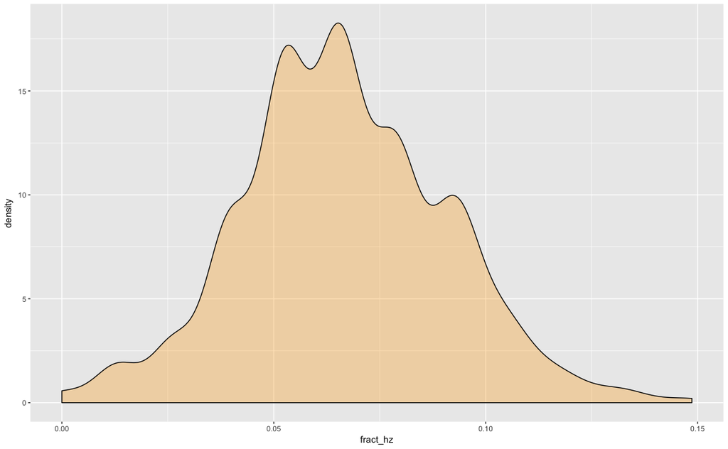

```r
ggplot(int_hz, aes(x = fract_hz)) +
  geom_density(fill = "orange", alpha = 0.3)
```

What an ugly thing! Also, the fract_hz is super low in this species. Maybe that means there were matching genotypes just because there is not enough variation in these markers in melanops.

## Let’s look for full-siblings

## Doing the pairwise comparisons

We need to flatten the CKMR object appropriately

```r
# flatten those out
fs_flat <- flatten_ckmr(CK, "FS")
unrel_flat <- flatten_ckmr(CK, "U")
# then compute the log-likelihoods for the full-sib relationship
fs_u_flat <- fs_flat
fs_u_flat$probs <- log(fs_flat$probs / unrel_flat$probs)
```

### Power for full-sib detection

First, we want to see what the distributions of FS/U LogLs look like for FS, U, and HS. This is pretty straightforward to do with the ckmr object we made:

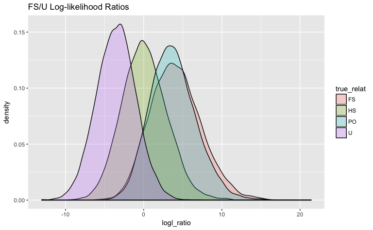

```r
fs_u <- extract_logls(Qs, numer = c(FS = 1), denom = c(U = 1))
ggplot(fs_u, aes(x = logl_ratio, fill = true_relat)) +
  geom_density(alpha = 0.25) +
  ggtitle("FS/U Log-likelihood Ratios")
```

There’s a lot of overlap between the distribution of full-sibs and the unrelated distribution. But if a comparision has a log-likelihood ratio well above 5, it might have potential.

| member1 | member2 | value | num_loc | name1 | name2 | stage1 | date1 | stage2 | date2 |
| --- | --- | --- | --- | --- | --- | --- | --- | --- | --- |
| 363 | 412 | 10.284459 | 74 | R035096 | R035626 | JUVENILE | 5/28/17 | JUVENILE | 9/7/17 |
| 249 | 408 | 10.174249 | 76 | R030421 | R035611 | JUVENILE | 7/20/16 | JUVENILE | 9/7/17 |
| 83 | 237 | 9.902329 | 76 | R026874 | R030395 | JUVENILE | 6/7/16 | JUVENILE | 7/20/16 |
| 248 | 412 | 9.546211 | 76 | R030418 | R035626 | JUVENILE | 7/20/16 | JUVENILE | 9/7/17 |
| 248 | 416 | 9.100777 | 76 | R030418 | R035635 | JUVENILE | 7/20/16 | JUVENILE | 9/7/17 |
| 218 | 336 | 8.838370 | 78 | R030351 | R030646 | JUVENILE | 7/6/16 | JUVENILE | 9/17/16 |
| 3 | 248 | 8.794152 | 74 | R026287 | R030418 | JUVENILE | 4/24/16 | JUVENILE | 7/20/16 |
| 3 | 143 | 8.762151 | 75 | R026287 | R030210 | JUVENILE | 4/24/16 | JUVENILE | 6/22/16 |
| 79 | 109 | 8.755841 | 75 | R026867 | R027009 | JUVENILE | 6/7/16 | JUVENILE | 6/7/16 |
| 143 | 248 | 8.717684 | 76 | R030210 | R030418 | JUVENILE | 6/22/16 | JUVENILE | 7/20/16 |

[output cut: 990 more lines]

Hard to know if any of these are really plausible given the overlapping distributions between unrelated and full-sibs.

In reality, we probably don’t just don’t have the power with these markers.